# generated_series

Волканова Маргарита

5 мая 2019 г

# 1 Реальный ряд

Данные: Ежемесячные продажи белого в тысячах литров с января 1980 года по июль 1995 года. Виноделами в бутылках объемом не более 1 литра. Многомерный временной ряд с 187 наблюдениями

```r
library(stats)
library(Rssa)
```

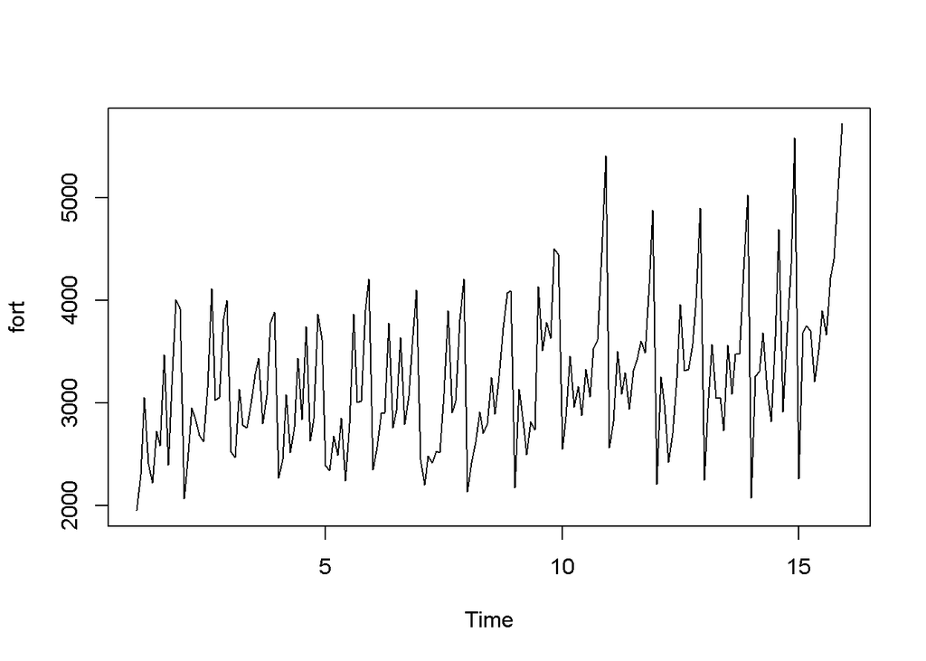

```r
data("AustralianWine")
wine <- window(AustralianWine, end = time(AustralianWine)[180])
fort <- ts(wine[, "Drywhite"],frequency = 12)
plot(fort)
```

Тренд возрастает,отдаленно напоминает линейный, но явно есть отклонения от него. Предполагаю, что модель мультипликативная, так как амплитуда колебаний ведет себя пропорционально тренду и шум пропорционален всему сигналу.

# 2 Разложение SSA

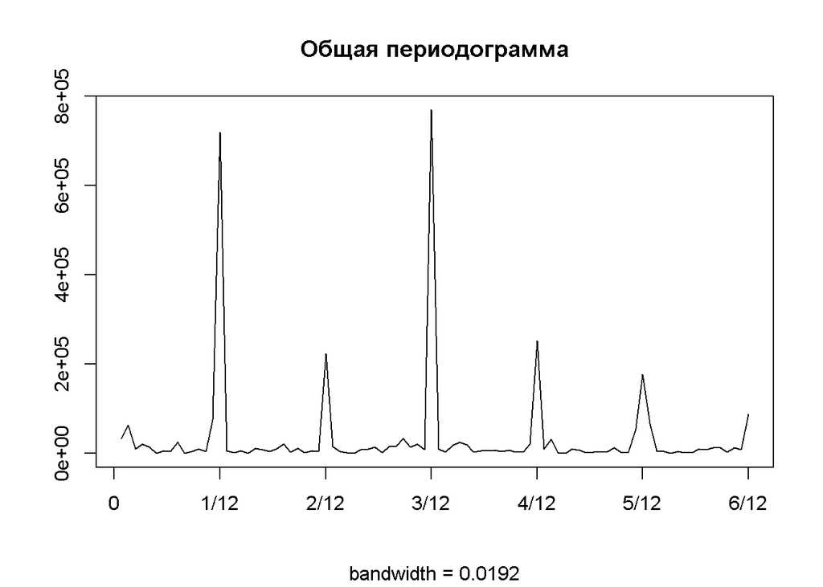

```r
spec.pgram(fort,log="no",detrend=TRUE,xaxt='n',fast =FALSE,main="Общая периодограмма",ann="False")
axis(1, at = c(0,1,2,3,4,5,6), labels = c('0', '1/12', '2/12', '3/12', '4/12', '5/12', '6/12'))
```

Из периодограммы видно, что есть сезонные компоненты с частотами 1/12, 2/12, 3/12, 4/12, 5/12,6/12.

Для разложения SSA надо использовать длину окна кратно периоду и максимально близкую к половине длины ряда.Взяла длину равную 60, чтобы компоненты сезонности смешивались меньше, теперь длина окна делится на все периоды.

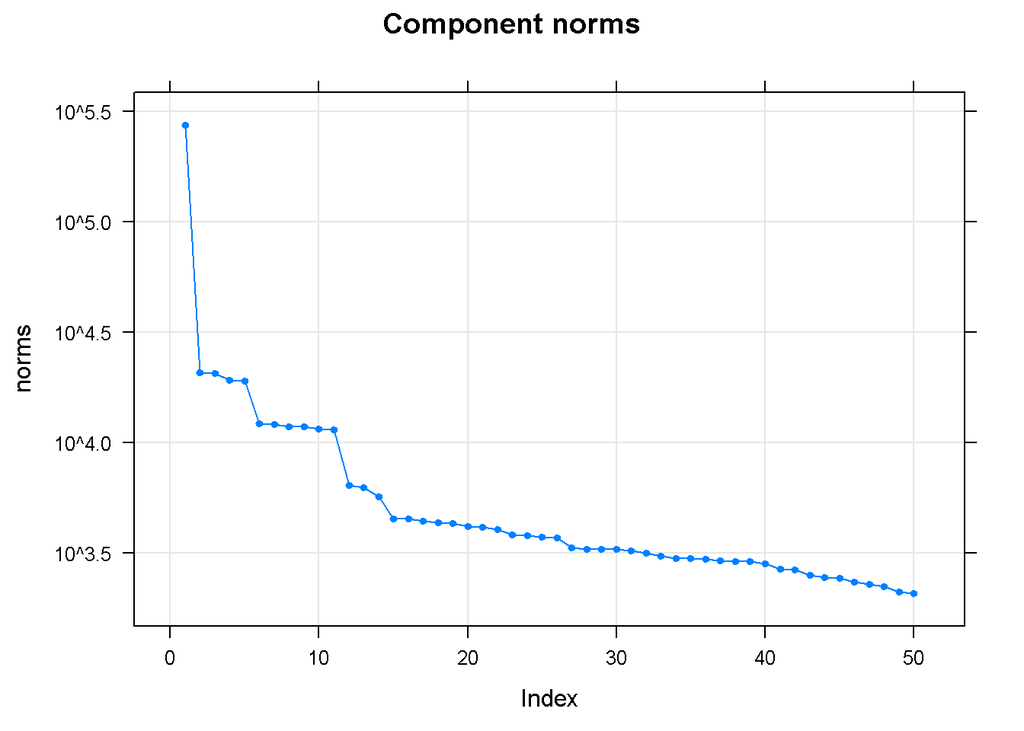

```r
ssa_fort <- ssa(fort, L = 60)
#График собственных чисел
plot(ssa_fort)
```

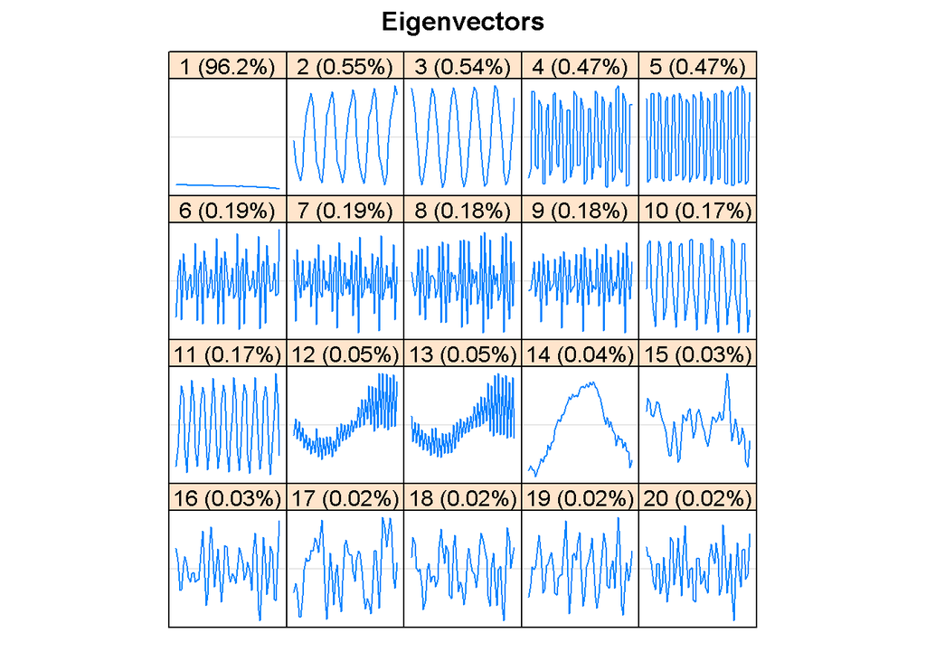

```r
#График одной компоненты
plot(ssa_fort, type = "vectors", idx = 1:20)
```

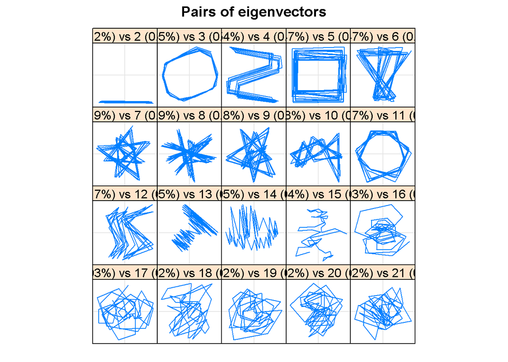

```r
#Рассмотрим парные графики
plot(ssa_fort,  type = "paired", idx = 1:20)
```

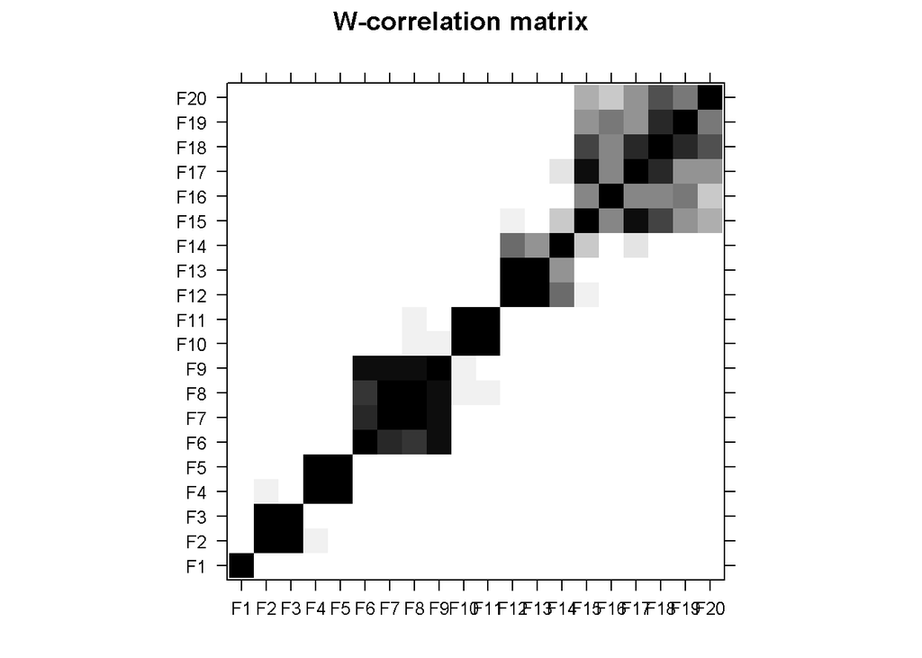

```r
#Корреляционная матрица.
plot(wcor(ssa_fort, groups = 1:20))
```

К тренду отнесем 1,14 компоненты, как медленно меняющиеся. Четко просматриваются такие гармоники, как 2:3, 4:5, 10:11. Судя по корреляционной матрице 6:9 очень плохо разделимы.

Сначала посмотрим как выделится тренд.

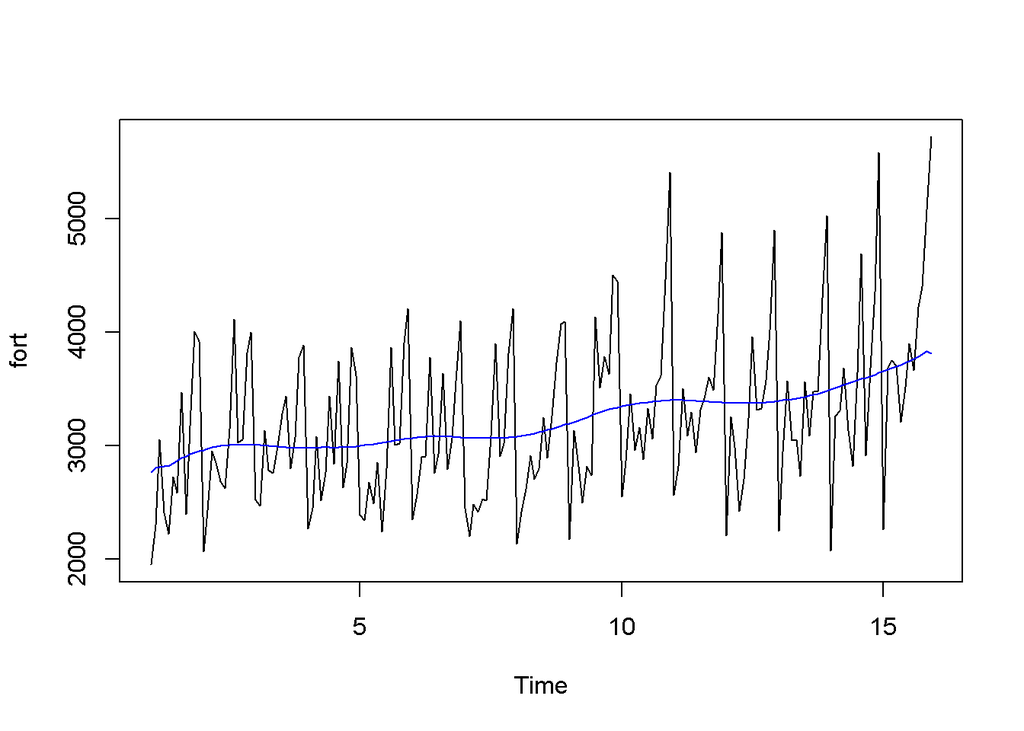

```r
fort_t_s<- reconstruct(ssa_fort , groups = list(trend = c(1,14),season = c(2:3,4:5,6:7,8:9,10:11,12:13)))
plot(fort,type='l')
lines(fort_t_s$trend,col="blue")
```

Мне нравится как выглядит.

Посмотрим периоды

```r
pe <- parestimate(ssa_fort, groups = list(1:14), method = "esprit")
pe
```

```
##    period     rate   |    Mod     Arg  |     Re        Im
##    -2.000   0.017825 |  1.01798  -3.14 | -1.01798  -0.00000
##     2.394   0.007841 |  1.00787   2.62 | -0.87629   0.49791
##    -2.394   0.007841 |  1.00787  -2.62 | -0.87629  -0.49791
##     5.984   0.002902 |  1.00291   1.05 |  0.49905   0.86992
##    -5.984   0.002902 |  1.00291  -1.05 |  0.49905  -0.86992
##     3.999   0.001691 |  1.00169   1.57 | -0.00031   1.00169
##    -3.999   0.001691 |  1.00169  -1.57 | -0.00031  -1.00169
##       Inf   0.001569 |  1.00157   0.00 |  1.00157   0.00000
##     3.003   0.001345 |  1.00135   2.09 | -0.49899   0.86816
##    -3.003   0.001345 |  1.00135  -2.09 | -0.49899  -0.86816
##    12.078   0.001305 |  1.00131   0.52 |  0.86885   0.49772
##   -12.078   0.001305 |  1.00131  -0.52 |  0.86885  -0.49772
##    72.816   0.001053 |  1.00105   0.09 |  0.99733   0.08627
##   -72.816   0.001053 |  1.00105  -0.09 |  0.99733  -0.08627
```

Одна пара с периодом 72 не относятся к сезонности. А так есть все что нужно, 2.4, 12,6,4,3,2.

Давайте посмотрим на периодическую составляющую ряда.

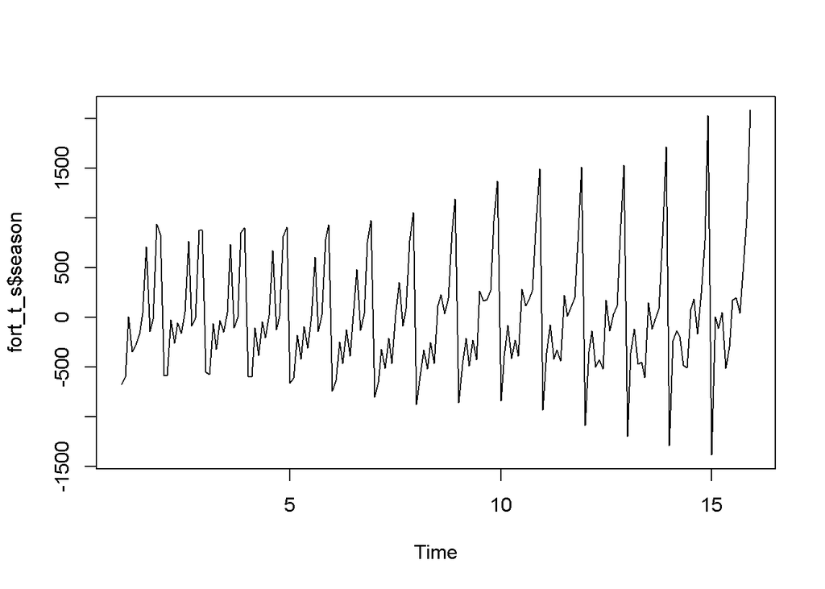

```r
plot(fort_t_s$season)
```

Автоматическая идентификация работает в условиях разделимости компонент, поэтому рассмотрим iossa и fossa сразу же.

# 3 Улучшение разложения - iossa и fossa

Хотим чтобы элементы были разделимы с учетом попарных гармоник 2:13.

## 3.1 Iossa

Попробуем улучшить слабую разделимость.

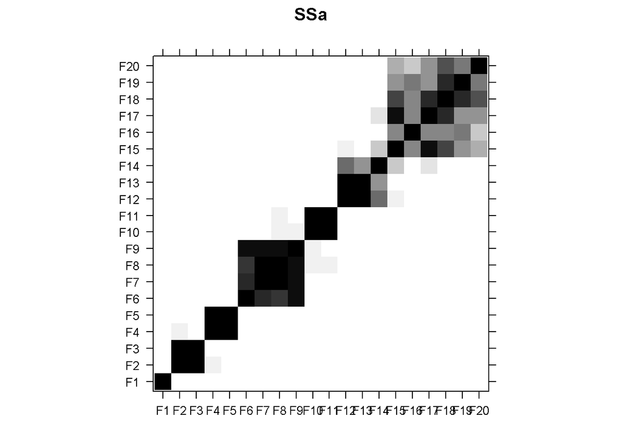

```r
#PS Хотела еще выделить 12:13, 14 - но мне там корреляционная матрица не понравилась
iossa_fort  <- iossa(ssa_fort , nested.groups = list(6:7,8:9,12:13,14), maxiter = 1000)
plot(wcor(ssa_fort, groups = 1:20), main = "SSa")
```

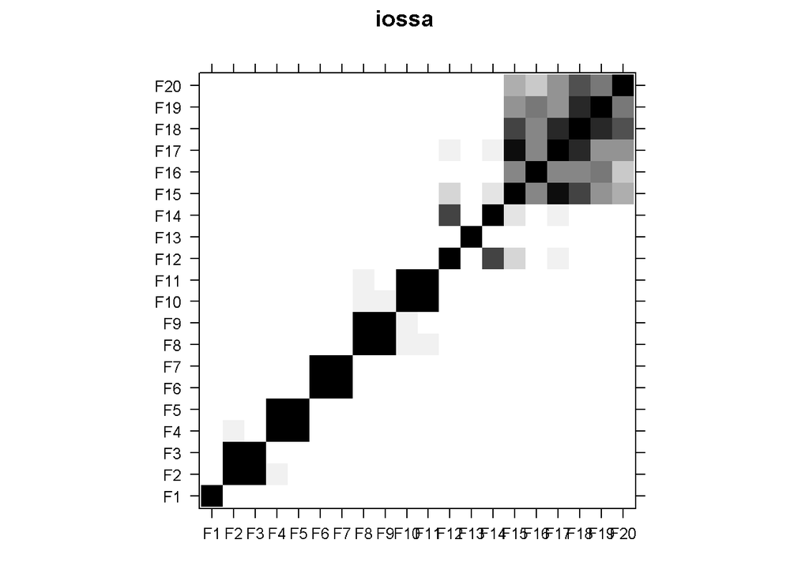

```r
plot(wcor(iossa_fort, groups = 1:20) , main = "iossa")
```

Видим, что красиво разделил гармоники 6:7, 8:9 и 13(пила), к тренду отнесем 1,12,14.

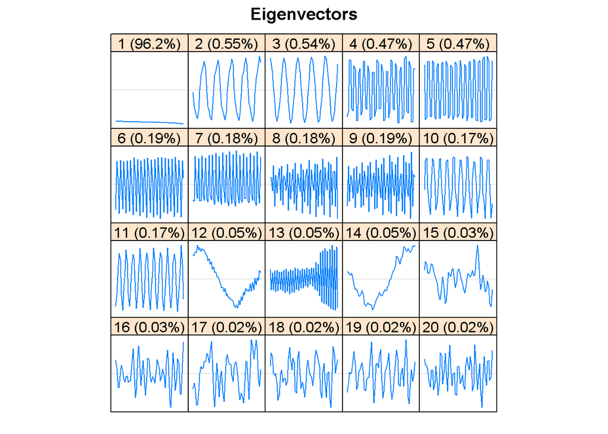

```r
#График одной компоненты
plot(iossa_fort, type = "vectors", idx = 1:20)
```

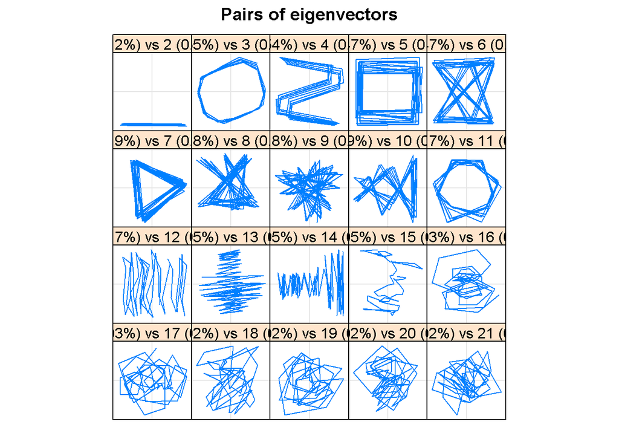

```r
#Рассмотрим парные графики
plot(iossa_fort,  type = "paired", idx = 1:20)
```

Сейчас очень классно видно 6:7 на парных графиках. У 8:9 видимо период 2.4. Если сравнить с исходными парными графиками, то на прошлых прям видно как они перемешались, особенно когда видишь, как разделил iossa.

Еще к тренду добавилась компонента 12. Давайте сравним с SSA.

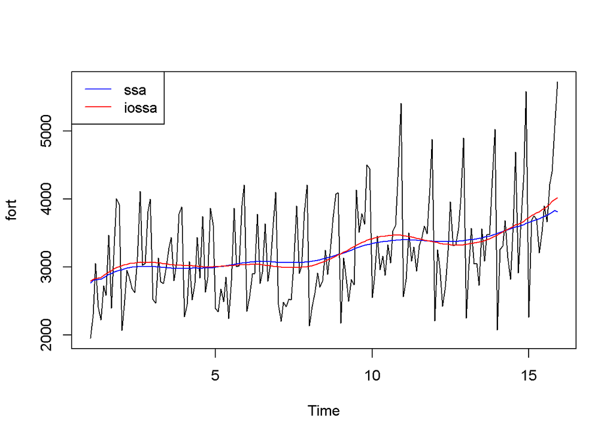

```r
io_re_fort <- reconstruct(iossa_fort, groups = list(trend = c(1,12,14),season = c(2:3,4:5,6:7,8:9,10:11,13)))
io_res_fort<- residuals(io_re_fort)
plot(fort,type='l')
lines(fort_t_s$trend,col="blue")
lines(io_re_fort$trend,col="red")
legend("topleft", legend = c( "ssa","iossa"), col = c("blue","red"), lty = 1)
```

Тренд более выпуклый в нужных местах. Считаю, что выделился лучше, чем при разложении SSA.

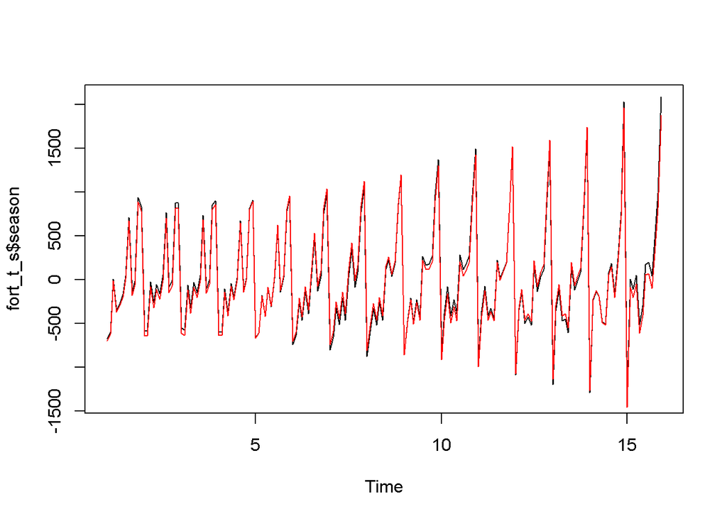

```r
plot(fort_t_s$season)
lines(io_re_fort$season,col="red")
```

Сезонность особо не поменялась.

Смотрим остатки и сразу на автокорреляцию:

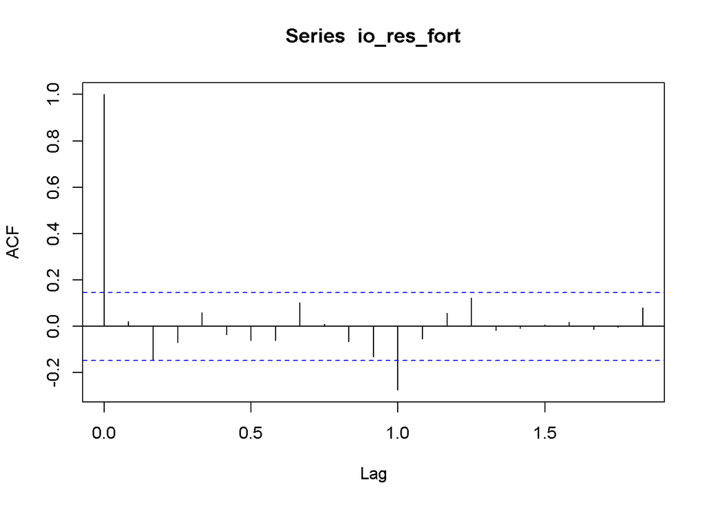

```r
acf(io_res_fort)
```

```r
Box.test(io_res_fort,  type = "Ljung-Box")
```

```
##
##  Box-Ljung test
##
## data:  io_res_fort
## X-squared = 0.07964, df = 1, p-value = 0.7778
```

Гипотеза, что шум является белым, не отвергается.

## 3.2 Fossa

Попробуем улучшить сильную разделимость.

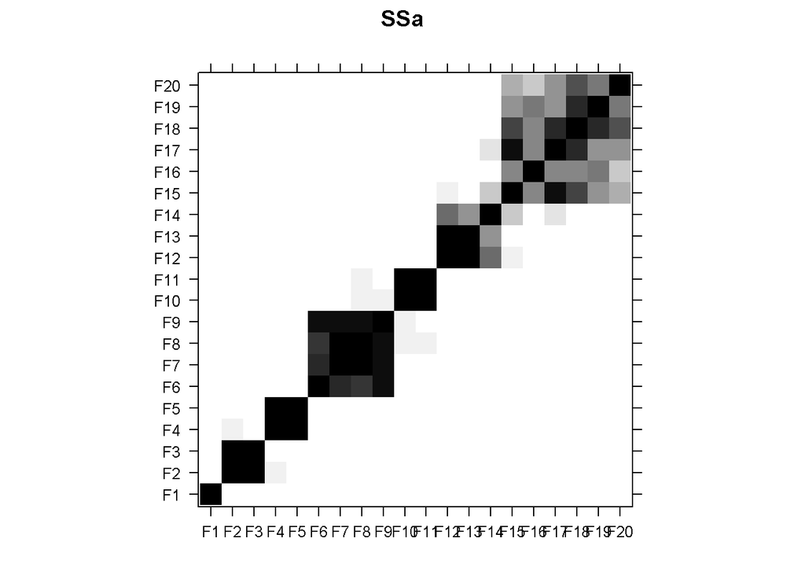

```r
fo_re_fort  <- fossa(ssa_fort , nested.groups = list(6:7,8:9,12:13,14), maxiter = 1000)
fo_res_fort<- residuals(fo_re_fort)
plot(wcor(ssa_fort, groups = 1:20), main = "SSa")
```

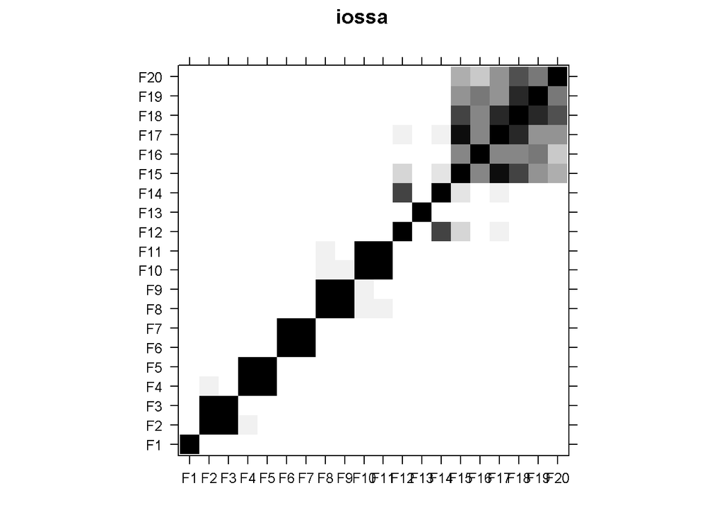

```r
plot(wcor(iossa_fort , groups = 1:20), main = "iossa")
```

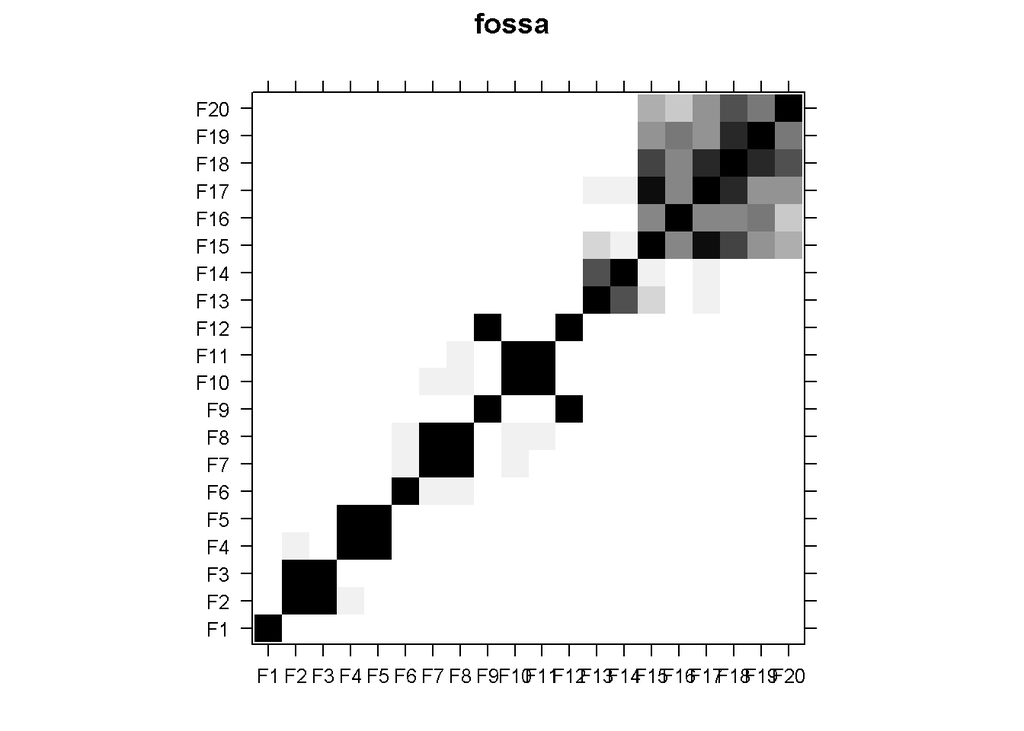

```r
plot(wcor(fo_re_fort , groups = 1:20), main = "fossa")
```

Видим, что у fossa чуть хуже и по-другому расположены парные и одинарные компоненты.

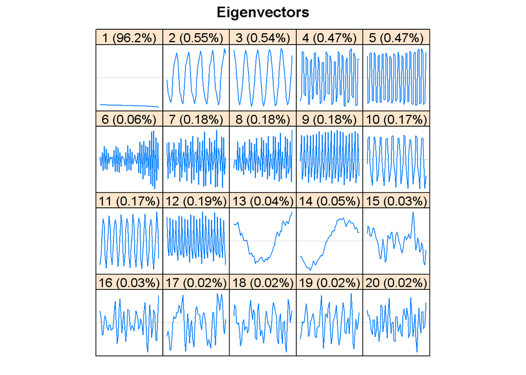

```r
#График одной компоненты
plot(fo_re_fort, type = "vectors", idx = 1:20)
```

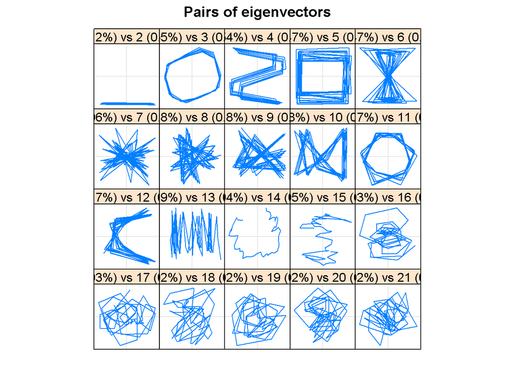

```r
#Рассмотрим парные графики
plot(fo_re_fort,  type = "paired", idx = 1:20)
```

Теперь по графику одной компоненты к тренду отнесем компоненты 1,13,14 как медленно меняющиеся. К сезонности отнесем по корреляционной матрице и по парным графикам 2:3,4:5,6,7:8,10:11.

[figure not shown]

Тренд почти не отличается от iossa.

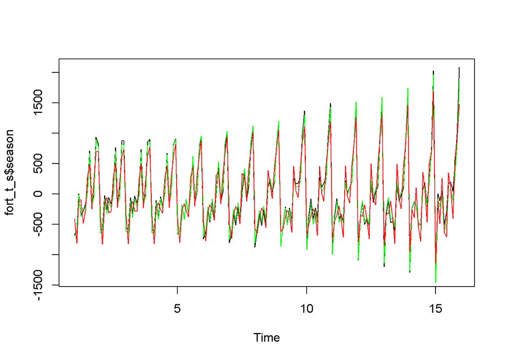

```r
plot(fort_t_s$season)
lines(io_re_fort$season,col="green")
lines(fo_re_fort$season,col="red")
```

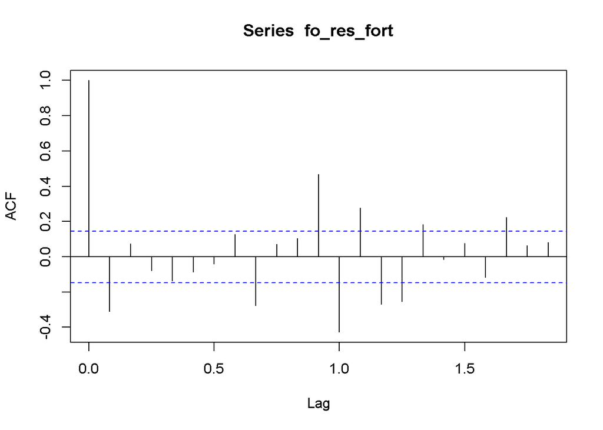

```r
acf(fo_res_fort)
```

```r
Box.test(fo_res_fort,  type = "Ljung-Box")
```

```
##
##  Box-Ljung test
##
## data:  fo_res_fort
## X-squared = 17.624, df = 1, p-value = 2.691e-05
```

И по тесту и по автокорреляции (в начале дуга) видно, что остатки не белый шум.

# 4 Автоматическая идентификация

(Или автоматическая группировка) Можно делать по матрице взвешенных корреляций, а также идентификацию тренда по периодограмме.

## 4.1 Частотная группировка

Рассмотрим группировку элементарных рядов с использованием периодограммы,группирует элементарные компоненты автоматически, используя их частотные вклады.

Параметры:

base = c(“series”, “eigen”, “factor”) – элементарные компоненты, собственные вектора или факторные вектора (то что подаем на вход периодограммы)

freq.bins – диапозон частот

threshold - порог вклада,«Порог» - это вектор, соответствующее значение порога будет использоваться для каждого интервала

Выделим тренд.

```r
library(Rssa)
ssa_fort <- ssa(fort, L = 60)
auto_component<-grouping.auto(ssa_fort,grouping.method="pgram",base = "series",threshold=0.80,freq.bins=c(1/24))
#threshold подобрала
auto_component$F1
```

```
## [1]  1 14
```

Изобразим получившийся тренд

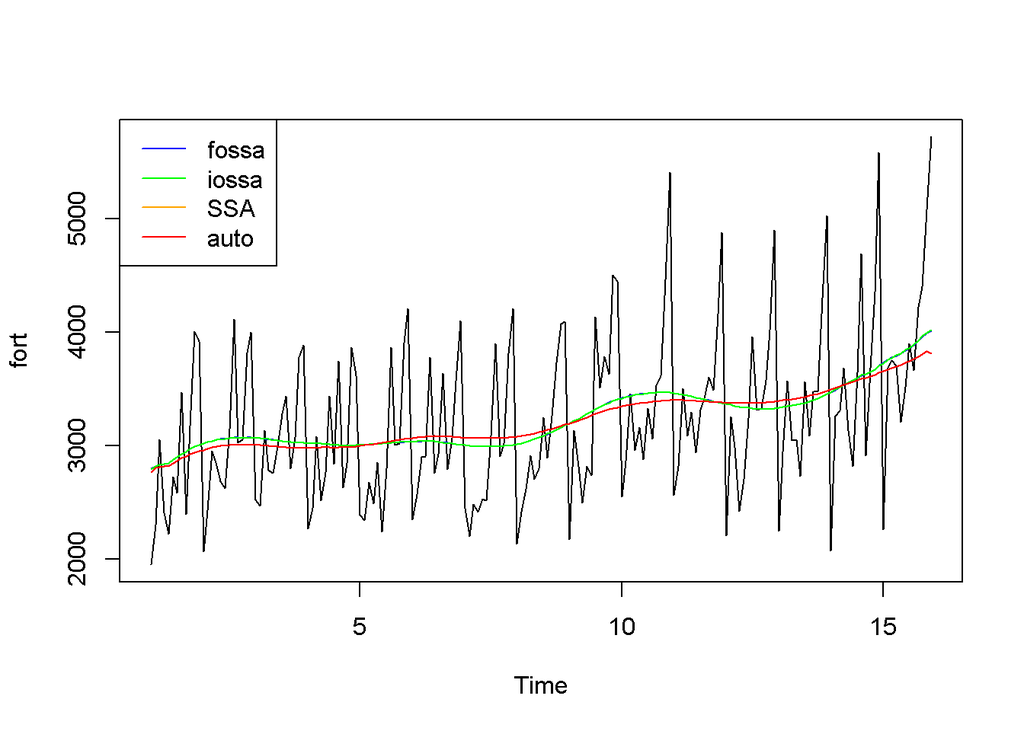

```r
auto_fort<- reconstruct(ssa_fort, list(groups = auto_component$F1))
auto_trend<-auto_fort$groups


plot(fort,type='l')

lines(fo_re_fort$trend,col="blue")
lines(io_re_fort$trend,col="green")
lines(fort_t_s$trend,col="orange")
lines(auto_trend,col='red')
legend("topleft", legend = c("fossa", "iossa","SSA","auto"), col =c("blue","green","orange","red"), lty = 1)
```

К прошлому графику тренда можно добавить, что ssa совпадает с auto.

Посмотрим на ряд без тренда.

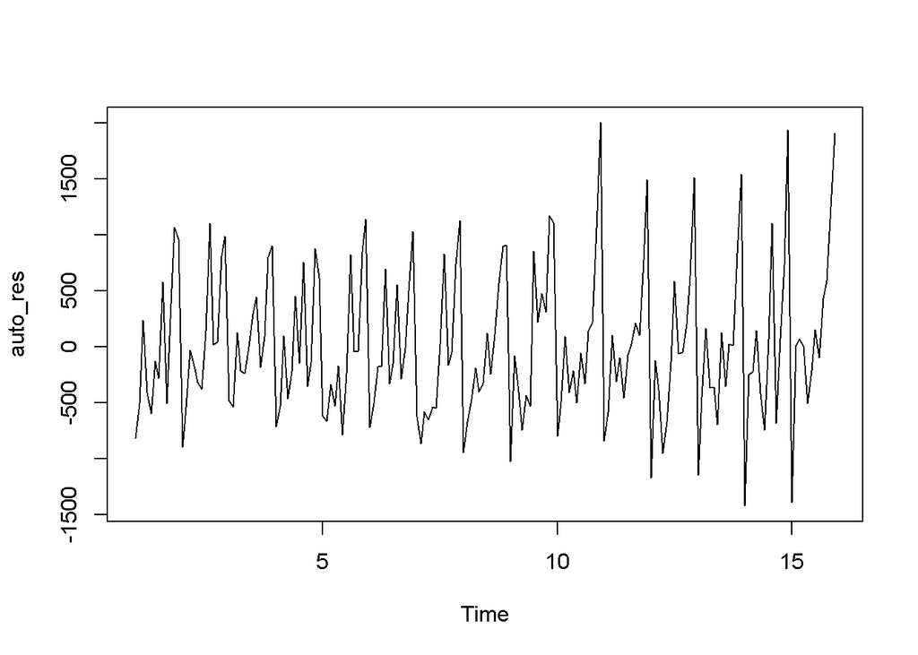

```r
auto_res<-fort-auto_trend
plot(auto_res)
```

## 4.2 Кластерная группировка

Теперь надо выделить периодическую составляющую ряда. Для этого воспользуемся группировкой на основе матрицы взвешенных корреляций.

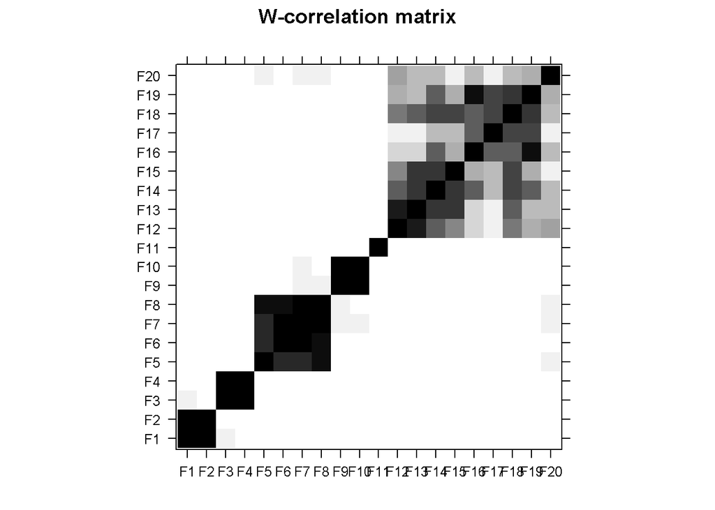

```r
#iossa_fort  <- iossa(ssa_fort , nested.groups = list(6:7,8:9,12:13,14), maxiter = 1000)
ser_res<-ssa(auto_res, L = 60)
plot(wcor(ser_res, groups = 1:20))
```

Как-то совсем все грустно с разделимостью, давайте воспользуемся iossa.

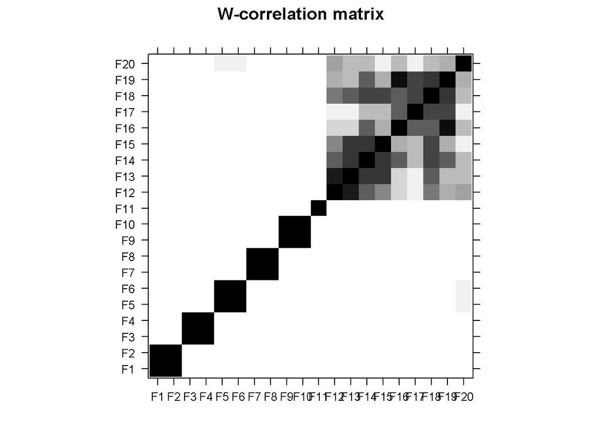

```r
ser_res  <- iossa(ser_res , nested.groups = list(1:2,3:4,5:6,7:8,9:10,11), maxiter = 1000)
#ser_res<-ssa(auto_res, L = 60)
plot(wcor(ser_res, groups = 1:20))
```

Хочу 6 кластеров для 5 компонент сезонности + остаток.

```r
#nclust целое число, желаемое количество выходных рядов
auto_component<-grouping.auto(ser_res,grouping.method="wcor",nclust=6)
auto_component[1:6]
```

```
## $`1`
## [1] 1 2
##
## $`2`
## [1] 3 4
##
## $`3`
## [1] 5 6
##
## $`4`
## [1] 7 8
##
## $`5`
## [1]  9 10
##
## $`6`
##  [1] 11 12 13 14 15 16 17 18 19 20 21 22 23 24 25 26 27 28 29 30 31 32 33
## [24] 34 35 36 37 38 39 40 41 42 43 44 45 46 47 48 49 50
```

Посмотрим парные графики.

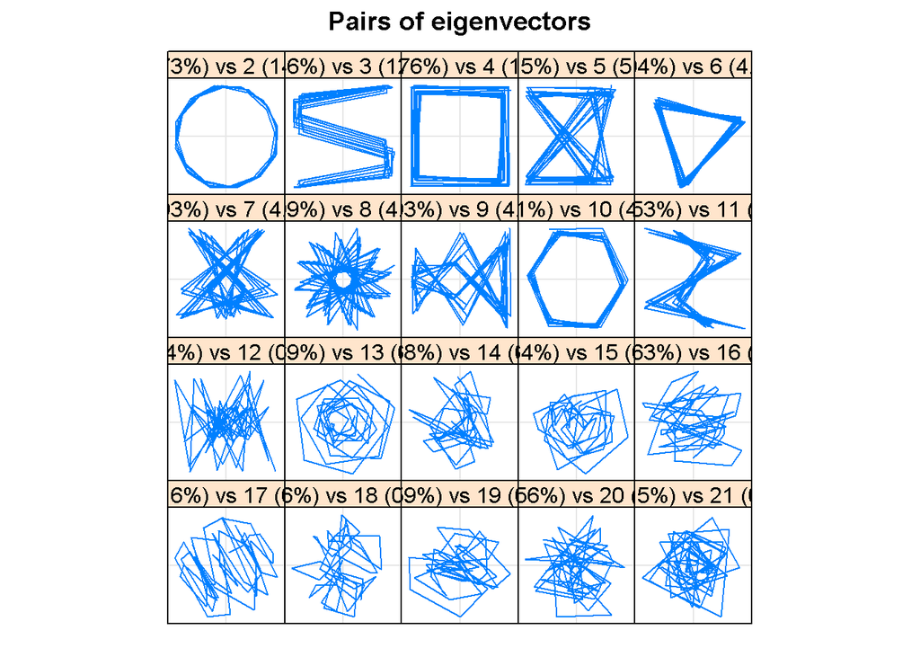

```r
plot(ser_res,  type = "paired", idx = 1:20)
```

Мне нравится как получилось. Посмотрим как получилась сезонность.

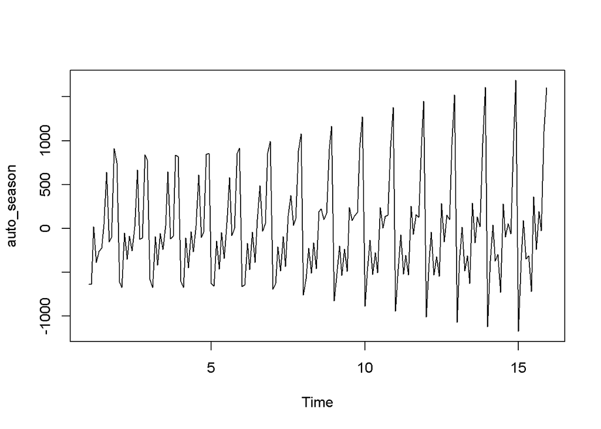

```r
season_rec <- reconstruct(ser_res, groups = auto_component)
auto_season<-season_rec$`1`+season_rec$`2`+season_rec$`3`+season_rec$`4`+season_rec$`5`
plot(auto_season)
```